# Workflow: Visium DLPFC

Source: https://lmweber.org/OSTA/pages/seq-workflow-dlpfc-spatiallibd.html

> This workflow analyzes a 10x Genomics Visium dataset consisting of one sample (Visium capture area) of postmortem human brain tissue from the dorsolateral prefrontal cortex (DLPFC) region, originally described by Maynard et al. (2021).

> The original full dataset contains 12 samples in total, from 3 donors, with 2 pairs of spatially adjacent replicates (serial sections) per donor (4 samples per donor). Each sample spans several cortical layers plus white matter in a tissue section. The examples in this workflow use a single representative sample, labeled 151673, which is often illustrated in various method papers in spatial omics data analysis.

### Dependencies

```r
suppressPackageStartupMessages({
  library(SpatialExperiment)
  library(STexampleData)
  library(ggspavis)
  library(patchwork)
  library(scater)
  library(scran)
  library(pheatmap)
})
```

### Workflow

First we’ll load the data

```r
spe <- STexampleData::Visium_humanDLPFC()
spe
```

```
class: SpatialExperiment
dim: 33538 4992
metadata(0):
assays(1): counts
rownames(33538): ENSG00000243485 ENSG00000237613 ... ENSG00000277475 ENSG00000268674
rowData names(3): gene_id gene_name feature_type
colnames(4992): AAACAACGAATAGTTC-1 AAACAAGTATCTCCCA-1 ... TTGTTTGTATTACACG-1 TTGTTTGTGTAAATTC-1
colData names(8): barcode_id sample_id ... reference cell_count
reducedDimNames(0):
mainExpName: NULL
altExpNames(0):
spatialCoords names(2) : pxl_col_in_fullres pxl_row_in_fullres
imgData names(4): sample_id image_id data scaleFactor
```

As an initial check, plot the spatial coordinates (spots) in x-y dimensions, to check that the object has loaded correctly. We use plotting functions from the ggspavis package.

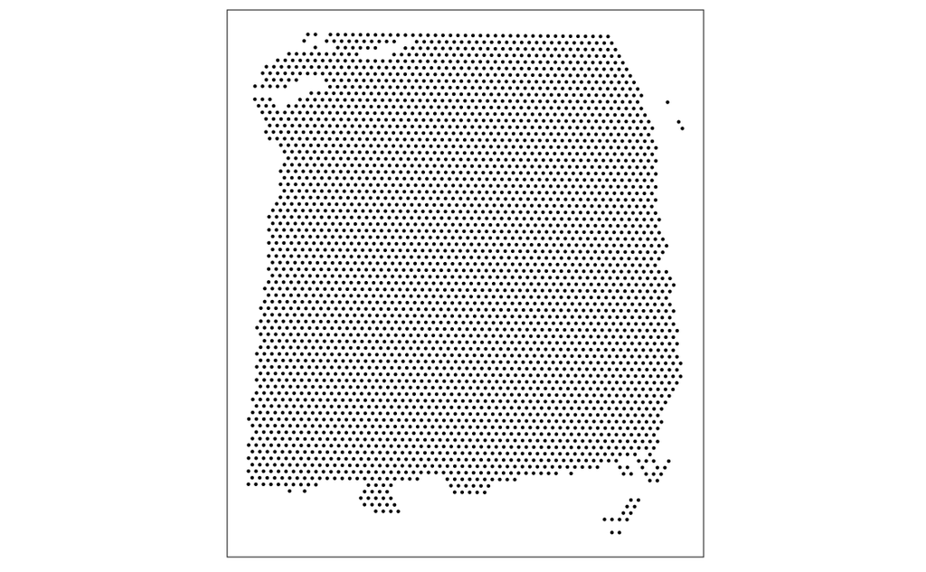

```r
# plot spatial coordinates (spots)
ggspavis::plotCoords(spe) # This is only available in >=bioc 3.21
```

### QC

> We calculate quality control (QC) metrics using the scater package (McCarthy et al. 2017), and apply simple global thresholding-based QC methods to identify any low-quality spots, as described in Section 9.3. More details, including more advanced QC approaches, are described in Chapter 9.

```r
dim(spe)
```

```
[1] 33538  4992
```

standard business:

```r
# ooooof. we have a mito gene file
is_mito <- grepl("(^MT-)|(^mt-)", rowData(spe)$gene_name)
spe <- addPerCellQC(spe, subsets = list(mito = is_mito))
```

this tutorial uses hists to pick global thresholds:

```r
par(mfrow = c(2, 2))
hist(spe$sum, xlab = "sum", main = "UMIs per spot")
hist(spe$detected, xlab = "detected", main = "Genes per spot")
```

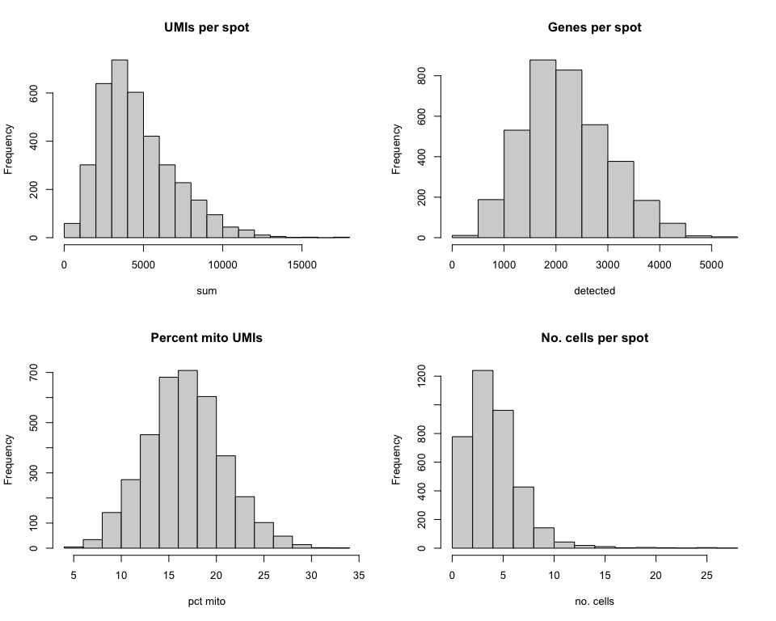

```r
hist(spe$subsets_mito_percent, xlab = "pct mito", main = "Percent mito UMIs")
hist(spe$cell_count, xlab = "no. cells", main = "No. cells per spot")
```

```r
# select global QC thresholds
spe$qc_lib_size <- spe$sum < 600
spe$qc_detected <- spe$detected < 400
spe$qc_mito <- spe$subsets_mito_percent > 28

# how much are we gonna lose? - we keep the FALSEs. TRUEs are discards
table(spe$qc_lib_size)
```

[output not shown]

```r
table(spe$qc_detected)
```

[output not shown]

```r
table(spe$qc_mito)
```

[output not shown]

there are some handy functions in `ggspavis` to visualize QC:

We particularly want to see if what we are discarding is concentrated in space or spread around.

> Plot the spatial distributions of the potentially identified low-quality spots, to ensure that they are not concentrated within biologically meaningful regions (which could suggest that the selected thresholds were too stringent).

```r
# plot spatial distributions of discarded spots
# the `annotate=` are colData columns with thresholds which we added in the last chunk
p1 <- plotObsQC(spe,
    plot_type = "spot",
    annotate = "qc_lib_size") +
    ggtitle("Library size (< threshold)")
p2 <- plotObsQC(spe,
    plot_type = "spot",
    annotate = "qc_detected") +
    ggtitle("Detected genes (< threshold)")
p3 <- plotObsQC(spe,
    plot_type = "spot",
    annotate = "qc_mito") +
    ggtitle("Mito proportion (> threshold)")

# arrange plots using patchwork package
p1 | p2 | p3
```

[output not shown]

Get a single discard vector in there and discard away.

```r
# combined set of identified spots
spe$discard <- spe$qc_lib_size | spe$qc_detected | spe$qc_mito
table(spe$discard)
plotObsQC(spe, plot_type = "spot", annotate = "discard")
```

[output not shown]

Stephanie DETOUR!

What’s going on with the other `plot_type` arguments here? From ggspavis docs:

> The following types of QC plots are available for spot-level or cell-level QC (see plotFeatureQC for feature-level QC):

> Histogram (plot_type = “histogram”) for a single QC metric, e.g. number of UMI counts per spot. For number of counts per spot, the histogram can optionally highlight selected spots, e.g. spots with low library size.

> Scatter plot (plot_type = “scatter”) comparing two QC metrics, e.g. number of detected features vs. number of cells per spot, with optional horizontal and vertical lines highlighting QC filtering thresholds.

> Spot plot (plot_type = “spot”) showing spots in spatial x-y coordinates, e.g. highlighting selected spots that do not meet filtering thresholds.

> Violin plot (plot_type = “violin”) for a single QC metric, e.g. number of UMI counts per spot. For number of counts per spot, the violin plot can optionally highlight selected spots, e.g. spots with low library size.

```r
head(colData(spe))
```

```
DataFrame with 6 rows and 18 columns
                           barcode_id     sample_id in_tissue array_row array_col ground_truth   reference cell_count       sum
                          <character>   <character> <integer> <integer> <integer>  <character> <character>  <integer> <numeric>
AAACAAGTATCTCCCA-1 AAACAAGTATCTCCCA-1 sample_151673         1        50       102       Layer3      Layer3          6      8458
AAACAATCTACTAGCA-1 AAACAATCTACTAGCA-1 sample_151673         1         3        43       Layer1      Layer1         16      1667
AAACACCAATAACTGC-1 AAACACCAATAACTGC-1 sample_151673         1        59        19           WM          WM          5      3769
AAACAGAGCGACTCCT-1 AAACAGAGCGACTCCT-1 sample_151673         1        14        94       Layer3      Layer3          2      5433
AAACAGCTTTCAGAAG-1 AAACAGCTTTCAGAAG-1 sample_151673         1        43         9       Layer5      Layer5          4      4278
AAACAGGGTCTATATT-1 AAACAGGGTCTATATT-1 sample_151673         1        47        13       Layer6      Layer6          6      4004
                    detected subsets_mito_sum subsets_mito_detected subsets_mito_percent     total qc_lib_size qc_detected   qc_mito
                   <integer>        <numeric>             <integer>            <numeric> <numeric>   <logical>   <logical> <logical>
AAACAAGTATCTCCCA-1      3586             1407                    13              16.6351      8458       FALSE       FALSE     FALSE
AAACAATCTACTAGCA-1      1150              204                    11              12.2376      1667       FALSE       FALSE     FALSE
AAACACCAATAACTGC-1      1960              430                    13              11.4089      3769       FALSE       FALSE     FALSE
AAACAGAGCGACTCCT-1      2424             1316                    13              24.2223      5433       FALSE       FALSE     FALSE
AAACAGCTTTCAGAAG-1      2264              651                    12              15.2174      4278       FALSE       FALSE     FALSE
AAACAGGGTCTATATT-1      2178              621                    13              15.5095      4004       FALSE       FALSE     FALSE
                     discard
                   <logical>
AAACAAGTATCTCCCA-1     FALSE
AAACAATCTACTAGCA-1     FALSE
AAACACCAATAACTGC-1     FALSE
AAACAGAGCGACTCCT-1     FALSE
AAACAGCTTTCAGAAG-1     FALSE
AAACAGGGTCTATATT-1     FALSE
```

```r
# yeah ok not impressive.
plotObsQC(spe, plot_type = "violin", x_metric = "qc_mito", y_metric = "subsets_mito_percent")
```

[output not shown]

END OF DETOUR!

Now we can actually discard.

```r
spe <- spe[, !spe$discard]
spe <- spe[, !spe$discard]
dim(spe)
```

```
[1] 33538  3614
```

## Normalization

Standard business: Make a simplified assumption that spots can be treated equivalently to single cells. Stephanie PSA: I can’t tell if this is a good option or not, but again I will also be going through the `SpaNorm` tutorial which is a package for spatially-aware normalization.

Importantly!!! -

> Some alternative non-spatial methods from scRNA-seq workflows (e.g. normalization by deconvolution) are also less appropriate for spot-based ST data, since spots can contain multiple cells from one or more cell types, and datasets can contain multiple samples (e.g. multiple tissue sections), which may result in sample-specific clustering.

^ Therefore, we don’t use `quickCluster()` with `computeSumFactors()` but instead take this simpler route:

```r
spe <- computeLibraryFactors(spe)
spe <- logNormCounts(spe)

spe
```

```
class: SpatialExperiment
dim: 33538 3614
metadata(0):
assays(2): counts logcounts
rownames(33538): ENSG00000243485 ENSG00000237613 ... ENSG00000277475 ENSG00000268674
rowData names(4): gene_id gene_name feature_type subsets_mito
colnames(3614): AAACAAGTATCTCCCA-1 AAACAATCTACTAGCA-1 ... TTGTTTGTATTACACG-1 TTGTTTGTGTAAATTC-1
colData names(19): barcode_id sample_id ... discard sizeFactor
reducedDimNames(0):
mainExpName: NULL
altExpNames(0):
spatialCoords names(2) : pxl_col_in_fullres pxl_row_in_fullres
imgData names(4): sample_id image_id data scaleFactor
```

### HVGs

> We use methods from the scran (Lun, McCarthy, and Marioni 2016) package, again making the simplified assumption that spots can be treated as equivalent to single cells. We also first remove mitochondrial genes, since these tend to be very highly expressed and are not of main biological interest

The tutorial indeed wholesale removes mito genes from the `spe` object. I’m not going to do that but I could..!

```r
# fit mean-variance relationship, decomposing variance into
# technical and biological components
gene_var <- modelGeneVar(spe)

# select top HVGs; they use prop = 0.1 but we often use num_genes so i'm doing that here. doesn't really matter.
top_hvgs <- getTopHVGs(gene_var, num_genes = 2000)
```

[output not shown]

Again there are also methods for spatially aware HVGs aka genes with high variability over space aka SVGs! I’ll look at those later.

> The set of SVGs may then be used either instead of or complementary to HVGs in subsequent steps.

### reduced dimensions

```r
spe <- runPCA(spe, subset_row = top_hvgs)
spe <- runUMAP(spe, dimred = "PCA")
```

Now, why on earth are we doing this? I’m not super sure. We already have a nice way to lay this out, that’s the point of the method. Why do we need to be in this reduced dimension to viz? OSTA gives no reasoning, it just plows on through.

### clustering

```r
colData(spe)
```

```
DataFrame with 3614 rows and 20 columns
                           barcode_id     sample_id in_tissue array_row array_col ground_truth   reference cell_count
                          <character>   <character> <integer> <integer> <integer>  <character> <character>  <integer>
AAACAAGTATCTCCCA-1 AAACAAGTATCTCCCA-1 sample_151673         1        50       102       Layer3      Layer3          6
AAACAATCTACTAGCA-1 AAACAATCTACTAGCA-1 sample_151673         1         3        43       Layer1      Layer1         16
AAACACCAATAACTGC-1 AAACACCAATAACTGC-1 sample_151673         1        59        19           WM          WM          5
AAACAGAGCGACTCCT-1 AAACAGAGCGACTCCT-1 sample_151673         1        14        94       Layer3      Layer3          2
AAACAGCTTTCAGAAG-1 AAACAGCTTTCAGAAG-1 sample_151673         1        43         9       Layer5      Layer5          4
...                               ...           ...       ...       ...       ...          ...         ...        ...
TTGTTTCACATCCAGG-1 TTGTTTCACATCCAGG-1 sample_151673         1        58        42           WM          WM          3
TTGTTTCATTAGTCTA-1 TTGTTTCATTAGTCTA-1 sample_151673         1        60        30           WM          WM          4
TTGTTTCCATACAACT-1 TTGTTTCCATACAACT-1 sample_151673         1        45        27       Layer6      Layer6          3
TTGTTTGTATTACACG-1 TTGTTTGTATTACACG-1 sample_151673         1        73        41           WM          WM         16
TTGTTTGTGTAAATTC-1 TTGTTTGTGTAAATTC-1 sample_151673         1         7        51       Layer2      Layer2          5
                         sum  detected subsets_mito_sum subsets_mito_detected subsets_mito_percent     total qc_lib_size
                   <numeric> <integer>        <numeric>             <integer>            <numeric> <numeric>   <logical>
AAACAAGTATCTCCCA-1      8458      3586             1407                    13              16.6351      8458       FALSE
AAACAATCTACTAGCA-1      1667      1150              204                    11              12.2376      1667       FALSE
AAACACCAATAACTGC-1      3769      1960              430                    13              11.4089      3769       FALSE
AAACAGAGCGACTCCT-1      5433      2424             1316                    13              24.2223      5433       FALSE
AAACAGCTTTCAGAAG-1      4278      2264              651                    12              15.2174      4278       FALSE
...                      ...       ...              ...                   ...                  ...       ...         ...
TTGTTTCACATCCAGG-1      4324      2170              370                    12              8.55689      4324       FALSE
TTGTTTCATTAGTCTA-1      2761      1560              314                    12             11.37269      2761       FALSE
TTGTTTCCATACAACT-1      2322      1343              476                    13             20.49957      2322       FALSE
TTGTTTGTATTACACG-1      2331      1420              308                    12             13.21321      2331       FALSE
TTGTTTGTGTAAATTC-1      6281      2927              991                    13             15.77774      6281       FALSE
                   qc_detected   qc_mito   discard sizeFactor    label
                     <logical> <logical> <logical>  <numeric> <factor>
AAACAAGTATCTCCCA-1       FALSE     FALSE     FALSE   1.834415        6
AAACAATCTACTAGCA-1       FALSE     FALSE     FALSE   0.361548        2
AAACACCAATAACTGC-1       FALSE     FALSE     FALSE   0.817440        4
AAACAGAGCGACTCCT-1       FALSE     FALSE     FALSE   1.178338        6
AAACAGCTTTCAGAAG-1       FALSE     FALSE     FALSE   0.927835        5
...                        ...       ...       ...        ...      ...
TTGTTTCACATCCAGG-1       FALSE     FALSE     FALSE   0.937812        4
TTGTTTCATTAGTCTA-1       FALSE     FALSE     FALSE   0.598820        4
TTGTTTCCATACAACT-1       FALSE     FALSE     FALSE   0.503608        1
TTGTTTGTATTACACG-1       FALSE     FALSE     FALSE   0.505559        1
TTGTTTGTGTAAATTC-1       FALSE     FALSE     FALSE   1.362256        6
```

plot it on the spots!!

```r
plotCoords(spe, annotate = "label", pal = "libd_layer_colors")
```

[output not shown]

They also plot a colored UMAP and again I am not sure why.

## Differential expression

> Identify marker genes for each cluster or spatial domain by testing for differentially expressed genes using pairwise t-tests, specifically testing for upregulation for each cluster or spatial domain.

They use scran for this; I don’t think an analysis like this would be in any intro workshop we teach though.

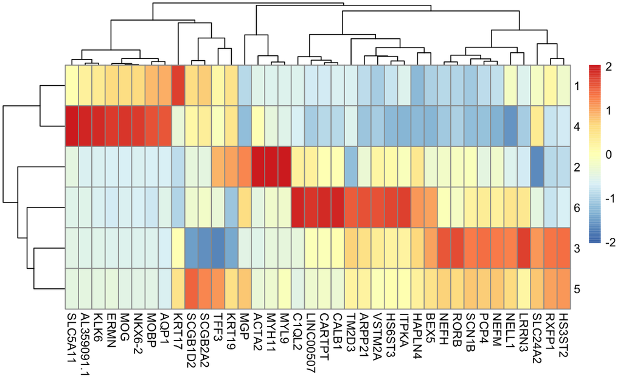

## spatialLBD

the rest of this tutorial walks through use of the `spatialLBD` package (at least one author is same as OSTA, so there you go).

> In this section, we will use the spatialLIBD package (Pardo et al. 2022) to continue analyzing this dataset by creating an interactive Shiny website to visualize the data.

This actually seems like an interesting tool but not one I think we want in a workshop? The steps involve setting up the object for use with the package, including GTF info, some other little variables to add in, and filtering. The package has a function to check the `spe` object, and then you can make a shiny website from it which really is neat just not at all reproducible.